# AN588_Malfunction_yunhuaz

Tiffany Zhu

### Write a simple R function, `Z.prop.test()`, that can perform one- or two-sample Z-tests for proportion data.

```r
z_prop <- function(p1,n1,p2 = NULL,n2 = NULL, p0, alternative = "two.sided", conf.level = 0.95) {
  # Function to check normality condition
  norm_approx <- function(p, n) {
    return(n * p > 5 && n * (1 - p) > 5)
  }

   # One-Sample Test
  if (is.null(p2) || is.null(n2)) {
    # Check Normal Approximation for one-sample test
    if (!norm_approx(p1, n1)) {
      warning("Normal approximation may not be valid for one-sample test")
    }

    # Calculate standard error and Z statistic
    se <- sqrt(p0 * (1 - p0) / n1)
    Z <- (p1 - p0) / se

    # Calculate p-value
    if (alternative == "two.sided") {
      P <- 2 * pnorm(-abs(Z))
    } else if (alternative == "less") {
      P <- pnorm(Z)
    } else if (alternative == "greater") {
      P <- pnorm(Z, lower.tail = FALSE)
    } else {
      stop("Invalid alternative hypothesis.")
    }

    # Confidence Interval for p1
    CI <- c(p1 - z_alpha * se, p1 + z_alpha * se)

  } else {

    #Two-Sample Test

    # Checking Normal Approximation for both samples
    if (!norm_approx(p1,n1) || !norm_approx(p2,n2)) {
      warning("Normal approximation may not be valid for two-sample test")
    }

    # Calculate Standard Error and Z stat
     se <- sqrt((p1 * (1 - p1)) / n1 + (p2 * (1 - p2)) / n2)
    Z <- (p1 - p2) / se

    # Calculate p-value
    if (alternative == "two.sided") {
      P <- 2 * pnorm(-abs(Z))
    } else if (alternative == "less") {
      P <- pnorm(Z)
    } else if (alternative == "greater") {
      P <- pnorm(Z, lower.tail = FALSE)
    } else {
      stop("Invalid alternative hypothesis.")
    }

    # Confidence Interval for (p1 - p2)
    CI <- c((p1 - p2) - z_alpha * se, (p1 - p2) + z_alpha * se)
  }

  # Return results
  return(list(Z = Z, P = P, CI = CI))
}
```

### The dataset from Kamilar and Cooper has in it a large number of variables related to life history and body size. For this exercise, the end aim is to fit a simple linear regression model to predict longevity (`MaxLongevity_m`) measured in months from species’ brain size (`Brain_Size_Species_Mean`) measured in grams. Do the following for both `longevity~brain size` and `log(longevity)~log(brain size)`:

```r
#Loading libraries
library(ggplot2)
library(dplyr)

# Setting Data up
setwd("C:/Users/yunhu/Documents/BI588/AN588_Malfunction_yunhuaz")
data <- read.csv("KamilarAndCooperData.csv")

#Model 1: Longevity ~ Brain Size
m1 <- lm(MaxLongevity_m ~ Brain_Size_Species_Mean, data = data)

# Model 2: Log(Longevity) ~ Log(Brain Size)
m2 <- lm(log(MaxLongevity_m) ~ log(Brain_Size_Species_Mean), data = data)
```

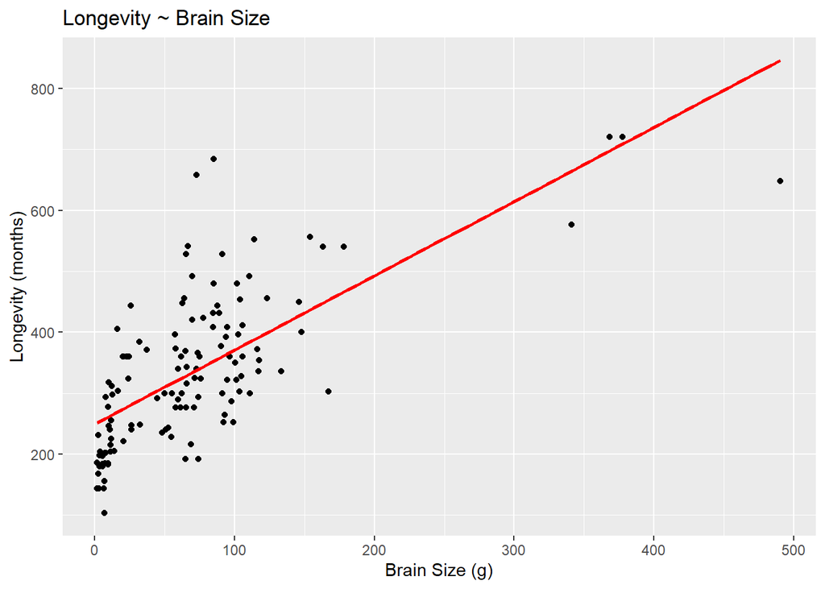

```r
# Scatterplots with fitted line for m1
plot1 <- ggplot(data, aes(x = Brain_Size_Species_Mean, y = MaxLongevity_m)) +
  geom_point() +
  geom_smooth(method = "lm", se = FALSE, color = "red") +
  geom_text(aes(x = max(Brain_Size_Species_Mean) * 0.8, y = max(MaxLongevity_m) * 0.9),
            label = paste("y =", round(coef(m1)[1], 2), "+", round(coef(m1)[2], 2), "x"),
            color = "blue") +
  labs(title = "Longevity ~ Brain Size",
       x = "Brain Size (g)",
       y = "Longevity (months)")

plot1
```

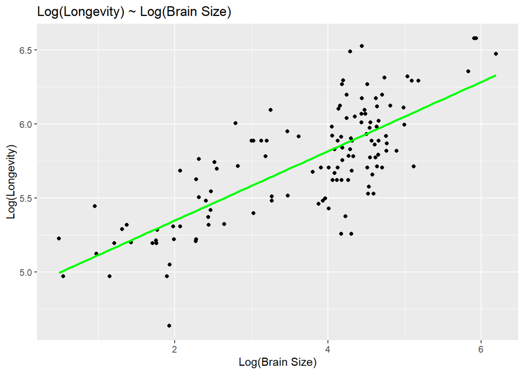

```r
# Scatterplot with fitted line for m2
plot2 <- ggplot(data, aes(x = log(Brain_Size_Species_Mean), y = log(MaxLongevity_m))) +
  geom_point() +
  geom_smooth(method = "lm", se = FALSE, color = "green") +
  geom_text(aes(x = max(log(Brain_Size_Species_Mean)) * 0.8, y = max(log(MaxLongevity_m)) * 0.9),
            label = paste("y =", round(coef(m2)[1], 2), "+", round(coef(m2)[2], 2), "x"),
            color = "purple") +
  labs(title = "Log(Longevity) ~ Log(Brain Size)",
       x = "Log(Brain Size)",
       y = "Log(Longevity)")

plot2
```

```r
# Interpret the Slope
# Store models in a list
models <- list(
  "Longevity ~ Brain Size" = m1,
  "Log(Longevity) ~ Log(Brain Size)" = m2
)
# Initialize an empty dataframe
results <- data.frame(
  Slope = numeric(),
  P_Value = numeric(),
  CI_Lower = numeric(),
  CI_Upper = numeric(),
  stringsAsFactors = FALSE
)

# Loop through each model
for (model_name in names(models)) {
  model <- models[[model_name]]

  # Extract slope (beta1)
  slope <- coef(model)[2]

  # Extract p-value for the slope
  p_value <- summary(model)$coefficients[2, 4]

  # Extract 90% confidence interval for the slope
  ci <- confint(model, level = 0.90)[2, ]

  # Add results to the dataframe
  results <- rbind(results, data.frame(
    Slope = slope,
    P_Value = p_value,
    CI_Lower = ci[1],
    CI_Upper = ci[2],
    stringsAsFactors = FALSE
  ))
}

results
```

```
##                                  Slope
## Brain_Size_Species_Mean      1.2179903
## log(Brain_Size_Species_Mean) 0.2341496
##                                   P_Value
## Brain_Size_Species_Mean      2.685909e-20
## log(Brain_Size_Species_Mean) 2.165214e-25
##                               CI_Lower  CI_Upper
## Brain_Size_Species_Mean      1.0355707 1.4004100
## log(Brain_Size_Species_Mean) 0.2046396 0.2636595
```

Hypothesis test:

H<sub>0</sub>: $β_{1} = 0$

There is no relationship between brain size mean and longevity.

H<sub>A</sub>: $β_{1} \neq 0$

There is a relationship between brain size mean and longevity.

The point estimate of the slope for the normal model is 1.21 with a 90% interval of (1.03, 1.40). For each one-unit increase in brain size, the longevity is estimated to increase by 1.21 units. The p-value of 2.68e-20 is less than 0.05, therefore we reject the null hypothesis suggesting that there is enough evidence to indicate a relationship between brain size and longevity.

The point estimate of the slope for the log-transformed model is 0.23 with a 90% interval of (0.20, 0.26). For each 1% increase in brain size, there is a 0.23% increase in longevity. The p-value of 2.16e-25 is less than 0.05, therefore we reject the null hypothesis suggesting that there is enough evidence to indicate a relationship between brain size and longevity.

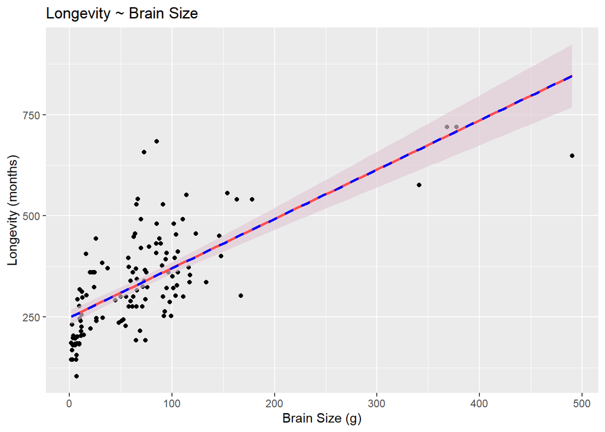

```r
# Adding 90% CI and PI to the m1 plot
plot1 <- plot1 +
  geom_smooth(method = "lm", se = TRUE, level = 0.90, color = "red", fill = "lightblue") +
  geom_smooth(method = "lm", se = TRUE, level = 0.90, color = "blue", fill = "pink", linetype = "dashed")

plot1
```

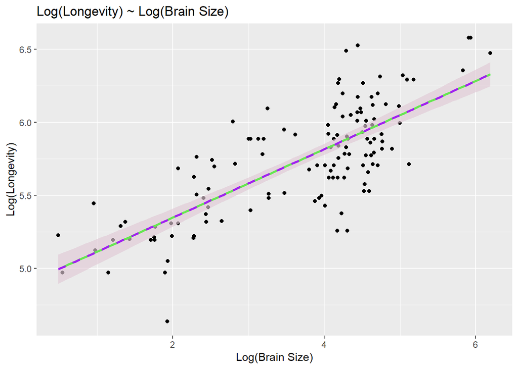

```r
# Adding 90% CI and PI to the m2 plot
plot2 <- plot2 +
  geom_smooth(method = "lm", se = TRUE, level = 0.90, color = "green", fill = "lightblue") +
  geom_smooth(method = "lm", se = TRUE, level = 0.90, color = "purple", fill = "pink", linetype = "dashed")

plot2
```

```r
# Setting data up
new_data <- data.frame(Brain_Size_Species_Mean = 800)

# Predicting longevity using normal model
predict1 <- predict(m1, newdata = new_data, interval = "prediction", level = 0.90)

# Predict log(longevity) using the log-transformed model
log_prediction <- predict(m2, newdata = new_data, interval = "prediction", level = 0.90)

# Convert the prediction back to the original scale (longevity in months)
predict2 <- exp(log_prediction)
```

```r
# Determining which model is better
# Extract R-squared values
r2_m1 <- summary(m1)$r.squared
r2_m2 <- summary(m2)$r.squared

# Combine predictions into a dataframe
comp_model <- data.frame(
  Model = c("Longevity ~ Brain Size", "Log(Longevity) ~ Log(Brain Size)"),
  Point_Estimate = c(predict1[1, "fit"], predict2[1, "fit"]),
  PI_Lower = c(predict1[1, "lwr"], predict2[1, "lwr"]),
  PI_Upper = c(predict1[1, "upr"], predict2[1, "upr"]),
  R_Squared = c(r2_m1, r2_m2),
  PI_Range = c(predict1[1, "upr"] - predict1[1, "lwr"], predict2[1, "upr"] - predict2[1, "lwr"])
)

comp_model
```

```
##                              Model Point_Estimate
## 1           Longevity ~ Brain Size      1223.3445
## 2 Log(Longevity) ~ Log(Brain Size)       629.0118
##    PI_Lower  PI_Upper R_Squared PI_Range
## 1 1021.8053 1424.8837 0.4927693 403.0784
## 2  412.1652  959.9446 0.5784088 547.7793
```

Using the normal model, the predicted longevity for a species with a brain weight of 800 grams is 1223.34 months, with a 90% prediction interval of (1021.80,1424.88).

Using the transformed model, the predicted longevity for a species with a brain weight of 800 grams is 629.01 months, with a 90% prediction interval of (412.16, 959.94).

The point estimate when predicting using both the normal model and log-transformed model data in between the 90% interval. However, the width of the PI intervals display uncertainty in both models. The normal model’s PI is 403.08 months wide while the log-transformed model’s PI is 547.78 months wide, the transformed model has a wider PI interval than normal model indicating there is more uncertainty. Due to this uncertainty and the large variation in predicted values between the two models, we should not fully trust the model’s predictions for this explanatory variable. The wide PIs suggest high variability in longevity, making it difficult to confidently predict individual observations.

The log-transformed model had an R-squared value of 0.57 while the normal model had an R-squared value of 0.49. Therefore the log-transformed model is a better fit for the data than the normal model as it fits the data more accurately.

## Issues

1. The length of the function made it difficult to keep track of brackets, leading to occasional errors. I had to retrace my steps multiple times to identify and correct missing or misplaced brackets.
2. I attempted to use for loops to quicken the process, but due to the varying types of data there was a lot of initializing elements. A manual approach might have been more efficient for this task.
3. To improve visualization, I created dataframes to organize the results. However, the extensive subsetting introduced minor errors like keeping track of bracket led me to believe a manual approach could have potentially also been more efficient.